# Summarizing Data: Quantitative Data Graphs

## Numerical and Graphical Summaries

- How to summarize data?
- Depends on data type:
  - Categorical
  - Quantitative

## Numerical and Graphical Summaries

- How to summarize quantitative data?
- Numerically?
- One Variable:
  - Measures of center
  - Mean, Median
  - Measures of spread
  - Variance, Standard Deviation, Quartiles, IQR
- Two Variables:
  - Measures of linear relationship
  - Covariance, Correlation
  - Can do any of above for subgroups of data!

## Graphical Summaries

**Quantitative Data** - plots use ggplot2

Recall:  
- Create base object  
- Add geom or stat layer(s) with aes mappings  
- Add label/title layers  
- Coordinate changes  
- Etc.

## Graphical Summaries

**Quantitative Data** - plots use ggplot2 (Histogram)

- Bins data to show distribution of observations

```r
g <- ggplot(CO2, aes(x = uptake))
g + geom_histogram()
```

## Graphical Summaries

**Quantitative Data** - plots use ggplot2 (Histogram)

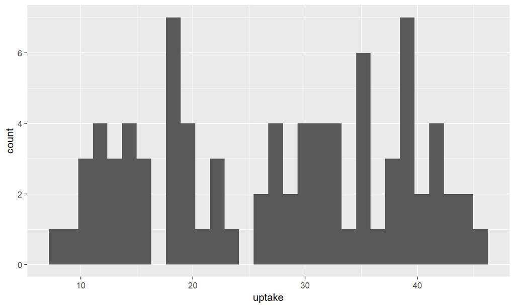

## Graphical Summaries

**Quantitative Data** - plots use ggplot2 (Histogram)

- Can change the look
- **Can manually change things** outside of `aes()`
- From cheat sheet:

`c + geom_histogram(binwidth = 5) x, y, alpha, color, fill, linetype, size, weight`

```r
g + geom_histogram(color = "blue", fill = "red",
                                     size = 2, binwidth = 3)
```

## Graphical Summaries

**Quantitative Data** - plots use ggplot2 (Histogram)

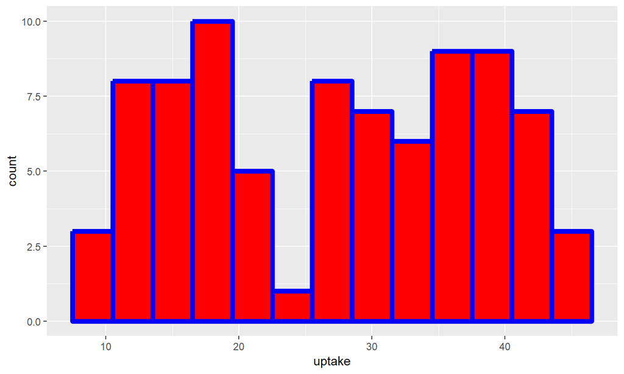

## Graphical Summaries

**Quantitative Data** - plots use ggplot2 (Kernel Smoother)

- Smoothed version of a histogram
- Kernel determines weight given to nearby points

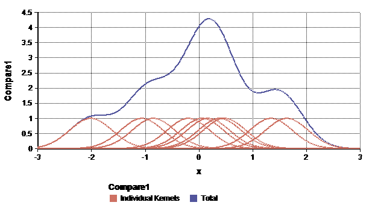

```r
g + geom_density()
```

## Graphical Summaries

**Quantitative Data** - plots use ggplot2 (Kernel Smoother)

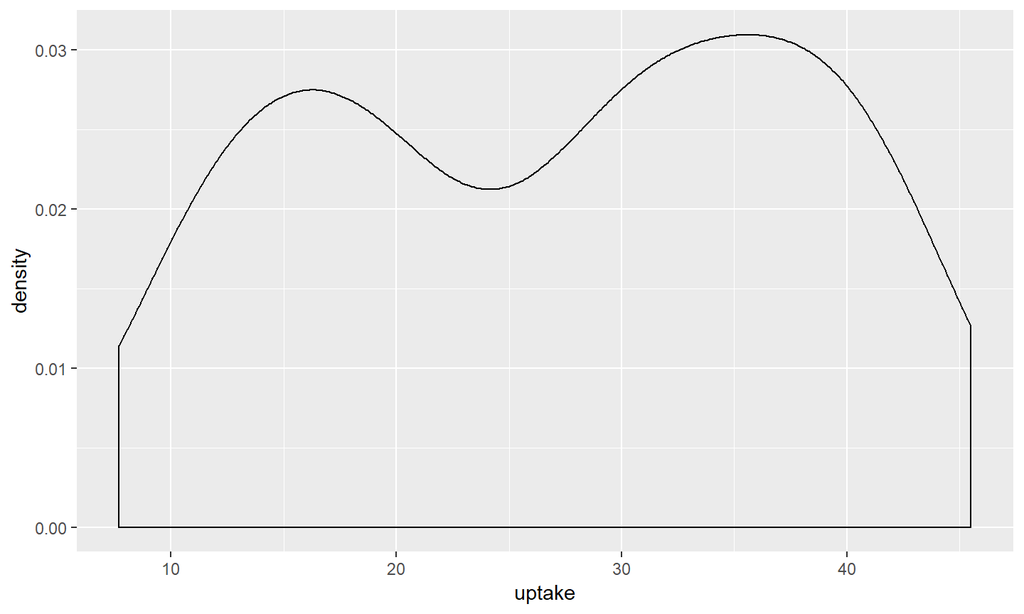

## Graphical Summaries

**Quantitative Data** - plots use ggplot2 (Kernel Smoother)

- Improve it with options!
- From cheat sheet:

`c + geom_density(kernel = "gaussian") x, y, alpha, color, fill, group, linetype, size, weight`

```r
g + geom_density(adjust = 0.5, alpha = 0.5, aes(fill = Treatment))
```

## Graphical Summaries

**Quantitative Data** - plots use ggplot2 (Kernel Smoother)

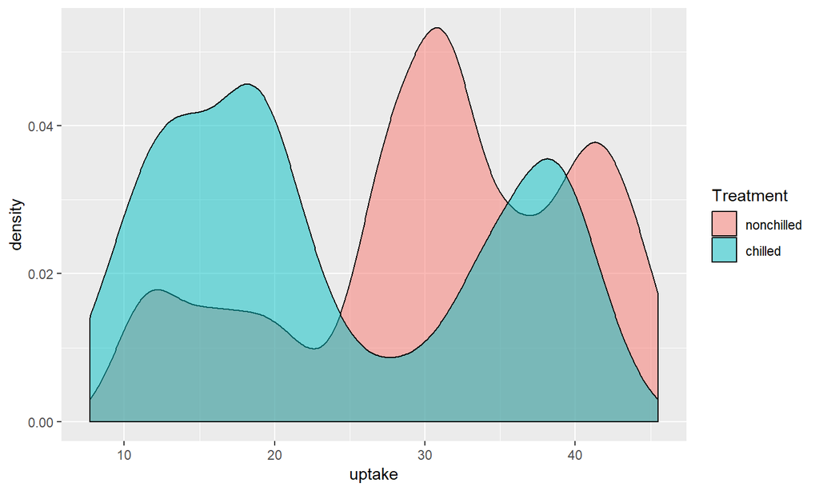

## Graphical Summaries

**Quantitative Data** - plots use ggplot2 (Kernel Smoother)

- Improve it with options!
- From cheat sheet:

`c + geom_density(kernel = "gaussian") x, y, alpha, color, fill, group, linetype, size, weight`

- recall `position` choices of `dodge`, `jitter`, `fill`, and `stack`

```r
g + geom_density(adjust = 0.5, alpha = 0.5, aes(fill = Treatment), position = "stack")
```

## Graphical Summaries

**Quantitative Data** - plots use ggplot2 (Kernel Smoother)

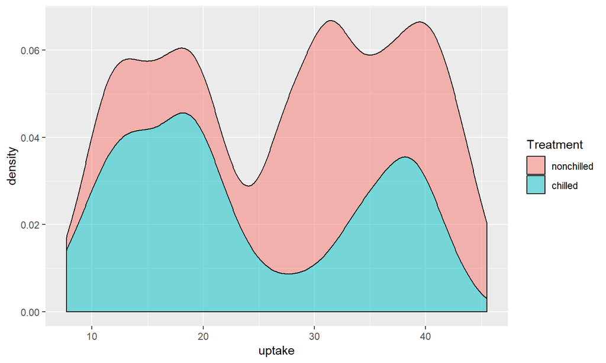

## Graphical Summaries

**Quantitative Data** - plots use ggplot2 (Histogram + Kernel Smoother)

```r
g + geom_histogram(aes(y = ..density.., fill = Treatment)) +
  geom_density(adjust = 0.25, alpha = 0.5, aes(fill = Treatment), position = "stack")
```

## Graphical Summaries

**Quantitative Data** - plots use ggplot2 (Histogram + Kernel Smoother)

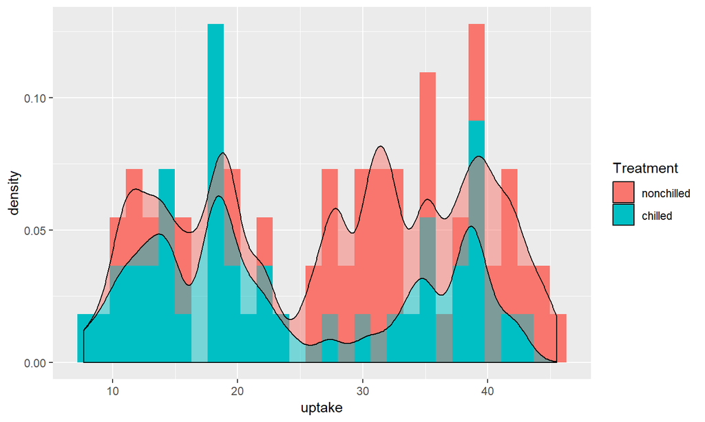

## Graphical Summaries

**Quantitative Data** - plots use ggplot2 (Histogram + Kernel Smoother)

- Better to set global `aes()` options here

```r
ggplot(CO2, aes(x = update, fill = Treatment)) + geom_histogram(aes(y = ..density..)) +
  geom_density(adjust = 0.25, alpha = 0.5)
```

- Can easily change fill variable for all layers now

## Graphical Summaries

**Quantitative Data** - plots use ggplot2 (ECDF)

- Empirical Cumulative Distribution Function (ECDF)
- At each point x, gives the proportion of points at or below x

```r
g + stat_ecdf(geom = "step")
```

## Graphical Summaries

**Quantitative Data** - plots use ggplot2 (ECDF)

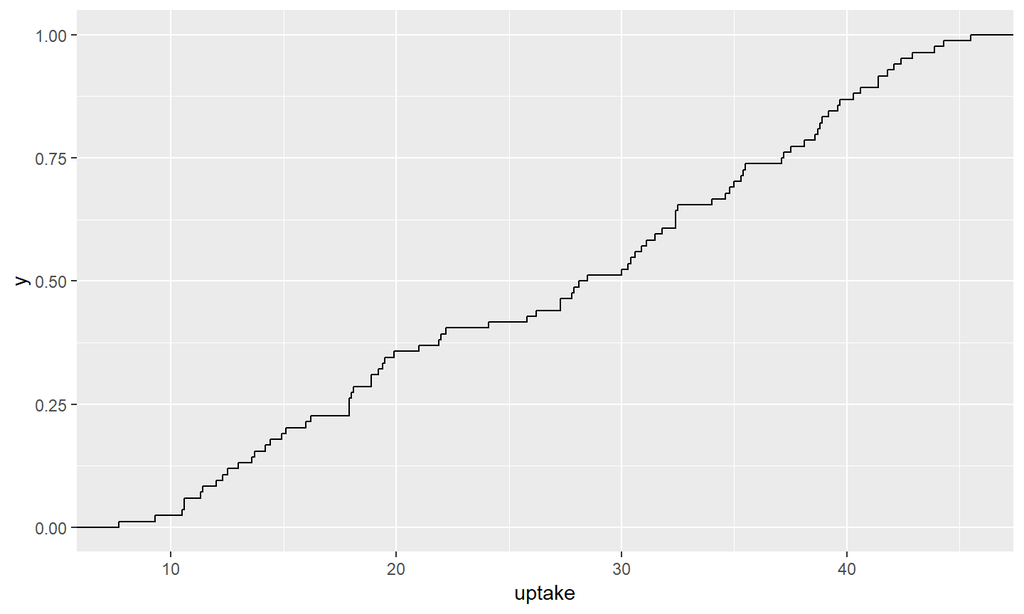

## Graphical Summaries

**Quantitative Data** - plots use ggplot2 (ECDF)

- Empirical Cumulative Distribution Function (ECDF)
- At each point x, gives the proportion of points at or below x
- For each treatment

```r
g + stat_ecdf(geom = "step", aes(color = Treatment)) +
  ylab("ECDF")
```

## Graphical Summaries

**Quantitative Data** - plots use ggplot2 (ECDF)

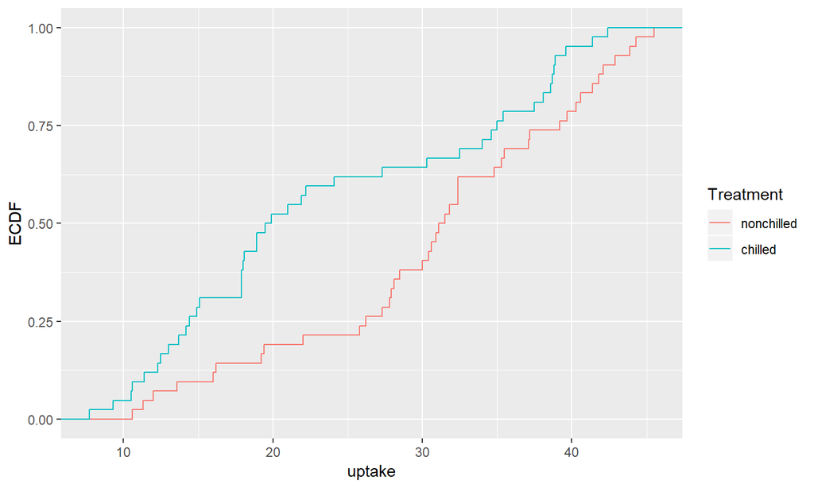

## Graphical Summaries

**Quantitative Data** - plots use ggplot2 (Scatter plot)

- Probably most used graph!
- Shows a point corresponding to each observation

```r
scoresFull <- read_csv("../datasets/scoresFull.csv")
scoresFull
```

```
## # A tibble: 3,471 x 82
##   week  date  day   season awayTeam   AQ1   AQ2   AQ3   AQ4   AOT  AOT2
##   <chr> <chr> <chr>  <int> <chr>    <int> <int> <int> <int> <int> <int>
## 1 1     5-Sep Thu     2002 San Fra~     3     0     7     6    -1    -1
## 2 1     8-Sep Sun     2002 Minneso~     3    17     0     3    -1    -1
## 3 1     8-Sep Sun     2002 New Orl~     6     7     7     0     6    -1
## 4 1     8-Sep Sun     2002 New Yor~     0    17     3    11     6    -1
## 5 1     8-Sep Sun     2002 Arizona~    10     3     3     7    -1    -1
## # ... with 3,466 more rows, and 71 more variables: AFinal <int>,
## #   homeTeam <chr>, HQ1 <int>, HQ2 <int>, HQ3 <int>, HQ4 <int>, HOT <int>,
## #   HOT2 <int>, HFinal <int>, stadium <chr>, startTime <time>, toss <chr>,
## #   roof <chr>, surface <chr>, duration <int>, attendance <chr>,
## #   weather <chr>, vegasLine <chr>, OU <chr>, AfirstDowns <int>,
## #   AnetPassYds <int>, AtotalYds <int>, Aturnovers <int>,
## #   AtotalPlays <int>, HfirstDowns <int>, HnetPassYds <int>,
## #   HtotalYds <int>, Hturnovers <int>, HtotalPlays <int>, OUvalue <dbl>,
## #   OUresult <chr>, awayRushAtt <int>, awayRushYds <int>,
## #   awayRushTD <int>, awayPassComp <int>, awayPassAtt <int>,
## #   awayPassYds <int>, awayPassTD <int>, awayPassInt <int>,
## #   awayTimesSacked <int>, awaySackYdsLost <int>, awayFum <int>,
## #   awayFumLost <int>, awayNumPen <int>, awayPenYds <int>,
## #   away3rdConv <int>, away3rdAtt <int>, away4thConv <int>,
## #   away4thAtt <int>, awayTOP <dbl>, homeRushAtt <int>, homeRushYds <int>,
## #   homeRushTD <int>, homePassComp <int>, homePassAtt <int>,
## #   homePassYds <int>, homePassTD <int>, homePassInt <int>,
## #   homeTimesSacked <int>, homeSackYdsLost <int>, homeFum <int>,
## #   homeFumLost <int>, homeNumPen <int>, homePenYds <int>,
## #   home3rdConv <int>, home3rdAtt <int>, home4thConv <int>,
## #   home4thAtt <int>, homeTOP <dbl>, HminusAScore <int>, homeSpread <dbl>
```

## Graphical Summaries

**Quantitative Data** - plots use ggplot2 (Scatter plot)

- Probably most used graph!
- Shows a point corresponding to each observation

```r
g <- ggplot(scoresFull, aes(x = homeRushYds, y = HFinal))
g + geom_point()
```

## Graphical Summaries

**Quantitative Data** - plots use ggplot2 (Scatter plot)

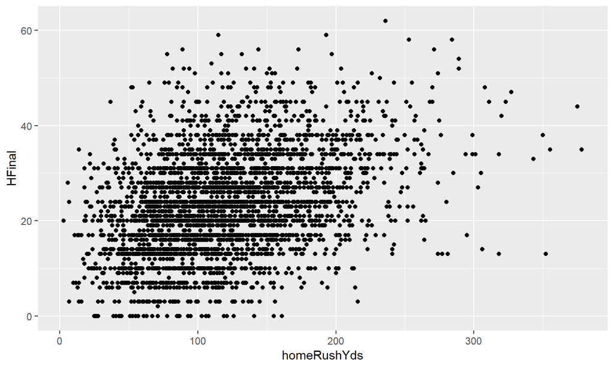

## Graphical Summaries

**Quantitative Data** - plots use ggplot2 (Scatter plot)

- Add trend lines (linear and gam - a fancy smoother)

```r
g + geom_point() +
    geom_smooth() +
    geom_smooth(method = lm, col = "Red")
```

## Graphical Summaries

**Quantitative Data** - plots use ggplot2 (Scatter plot)

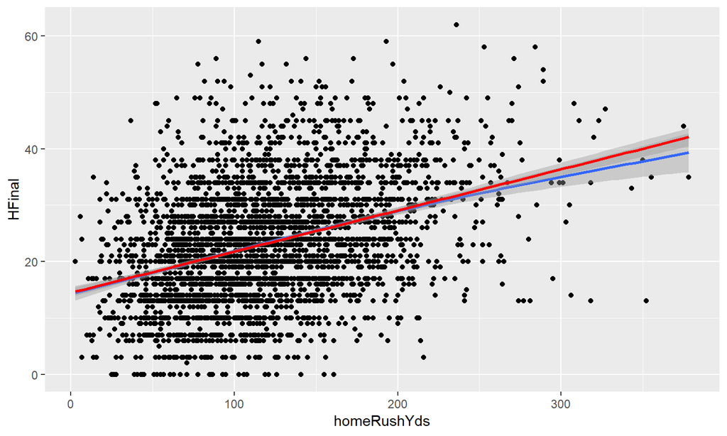

## Graphical Summaries

**Quantitative Data** - plots use ggplot2 (Scatter plot)

- May want to add text to plot
- Ex: Add value of correlation to plot

## Graphical Summaries

**Quantitative Data** - plots use ggplot2 (Scatter plot)

- May want to add text to plot
- Ex: Add value of correlation to plot
- `paste()` or `paste0()` handy

```r
paste("Hi", "What", "Is", "Going", "On", "?", sep = " ")
```

```
## [1] "Hi What Is Going On ?"
```

```r
paste("Hi", "What", "Is", "Going", "On", "?", sep = ".")
```

```
## [1] "Hi.What.Is.Going.On.?"
```

## Graphical Summaries

**Quantitative Data** - plots use ggplot2 (Scatter plot)

- Ex: Add value of correlation to plot

```r
correlation <- cor(scoresFull$homeRushYds, scoresFull$HFinal)

g + geom_point() +
    geom_smooth() +
    geom_smooth(method = lm, col = "Red") +
    geom_text(x = 315, y = 10, size = 5, label = paste0("Correlation = ",
                                             round(correlation, 2)))
```

## Graphical Summaries

**Quantitative Data** - plots use ggplot2 (Scatter plot)

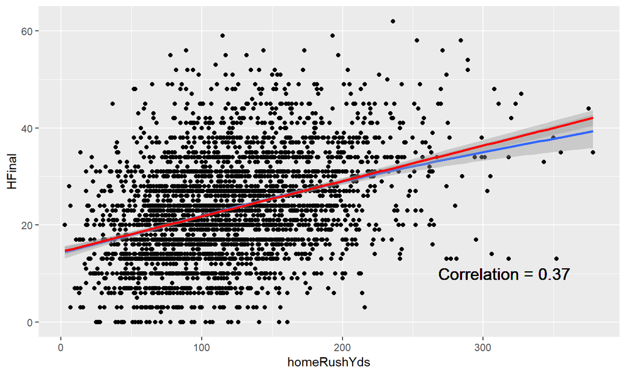

## Graphical Summaries

**Quantitative Data** - plots use ggplot2 (Scatter plot)

- Or could just plot a label instead of points!

```r
scores2 <- filter(scoresFull, homeTeam == "Pittsburgh Steelers")
g2 <- ggplot(scores2, aes(x = homeRushYds, y = HFinal))
g2 + geom_text(aes(label = season))
```

## Graphical Summaries

**Quantitative Data** - plots use ggplot2 (Scatter plot)

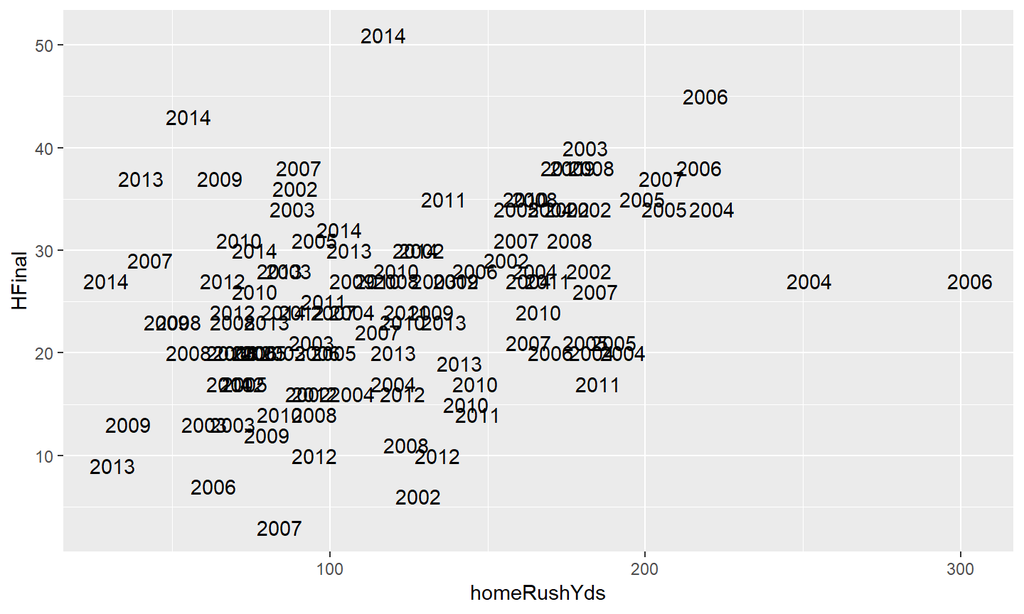

## Graphical Summaries

**Quantitative Data** - plots use ggplot2 (Scatter plot)

- Look at subplots broken down by other variables (usually categorical or use `cut()` to create them from continuous variables)
- Use `facet_grid()` or `facet_wrap()`

```r
g + geom_point() +
    facet_wrap(~ surface)
```

## Graphical Summaries

**Quantitative Data** - plots use ggplot2 (Scatter plot)

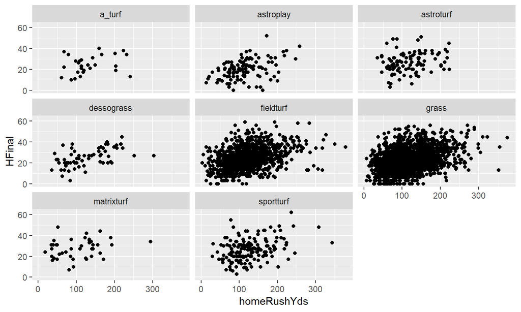

## Graphical Summaries

**Quantitative Data** - plots use ggplot2 (Scatter plot)

- Look at subplots broken down by other variables (usually categorical or use `cut()` to create them from continuous variables)
- Use `facet_grid()` or `facet_wrap()`

```r
g + geom_point() +
    facet_grid(roof ~ surface)
```

## Graphical Summaries

**Quantitative Data** - plots use ggplot2 (Scatter plot)

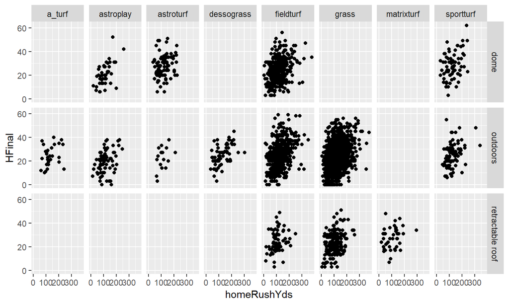

## Graphical Summaries

**Quantitative Data** - plots use ggplot2 (Scatter plot)

- Can still do all the fancy stuff to each plot!

```r
g + geom_point(aes(col = homeSpread), alpha = 0.6, size = 0.8, position = "jitter") +
    facet_wrap(~ roof)
```

## Graphical Summaries

**Quantitative Data** - plots use ggplot2 (Scatter plot)

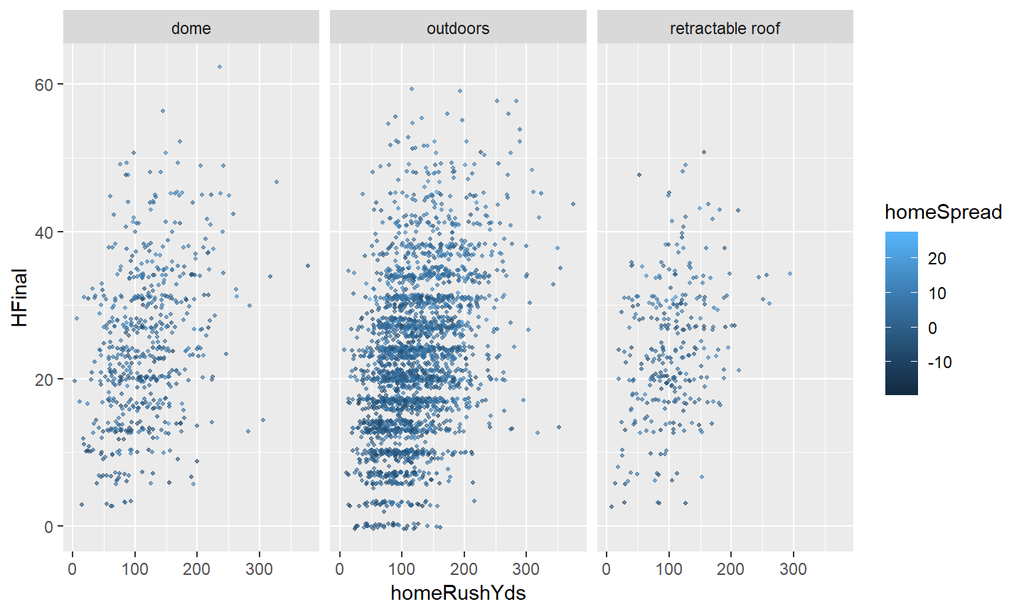

## Graphical Summaries

**Quantitative Data** - (Correlation)

- Create a visual of the correlations

```r
Correlation <- cor(select(scoresFull, Hturnovers, homeRushYds,
                        homePassYds, HFinal), method = "spearman")
#install corrplot library
library(corrplot)
```

```r
corrplot(Correlation, type = "upper",
         tl.pos = "lt")
corrplot(Correlation, type = "lower", method = "number",
         add = TRUE, diag = FALSE, tl.pos = "n")
```

## Graphical Summaries

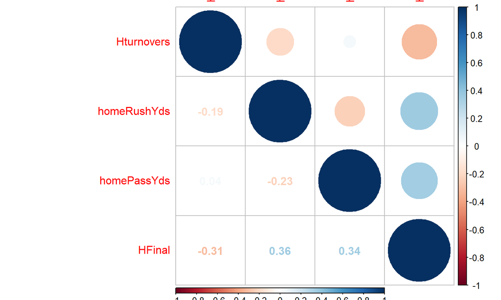

## Graphical Summaries

**Quantitative Data** - (Correlation)

- Really nice for many variables

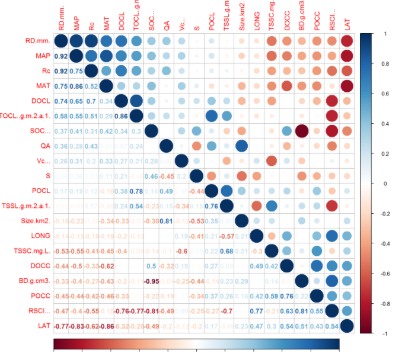

## Graphical Summaries

**Quantitative Data** - General plots

- Even better, use `ggpairs()` from `GGally` package
- Allows for auto creation with both quantitative and categorical data

```r
#install GGally
library(GGally)
```

```r
ggpairs(iris, aes(colour = Species, alpha = 0.4))
```

## Graphical Summaries

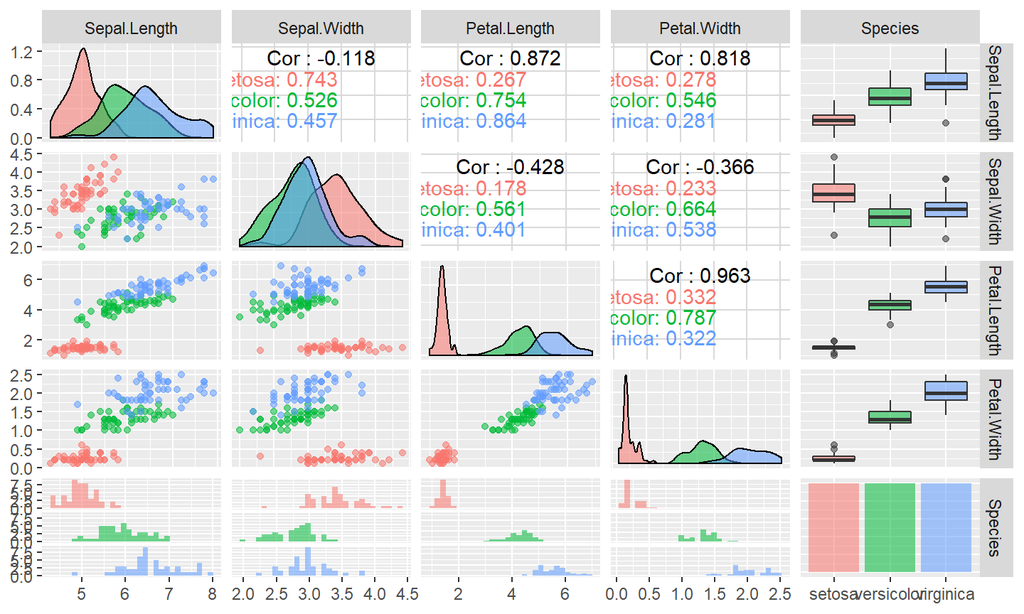

## Graphical Summaries

**Quantitative Data** - plots use ggplot2 (Boxplot)

- Boxplots provide the five number summary in a graph
  - min, Q1, median, Q3, max
  - Often show possible outliers as well

## Graphical Summaries

**Quantitative Data** - plots use ggplot2 (Boxplot)

```r
g <- ggplot(scoresFull, aes(x = surface, y = homePassYds))
g + geom_boxplot(fill = "grey")
```

## Graphical Summaries

**Quantitative Data** - plots use ggplot2 (Boxplot)

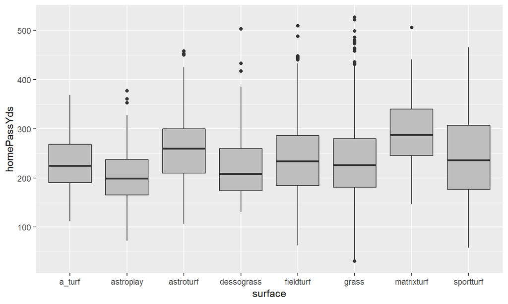

## Graphical Summaries

**Quantitative Data** - plots use ggplot2 (Boxplot)

- Get very fancy
- Add in lines connecting means for each group

```r
g + geom_boxplot(fill = "grey") +
    stat_summary(fun.y = mean, geom = "line",
                 lwd = 1.5, aes(group = roof, col = roof))
```

## Graphical Summaries

**Quantitative Data** - plots use ggplot2 (Boxplot)

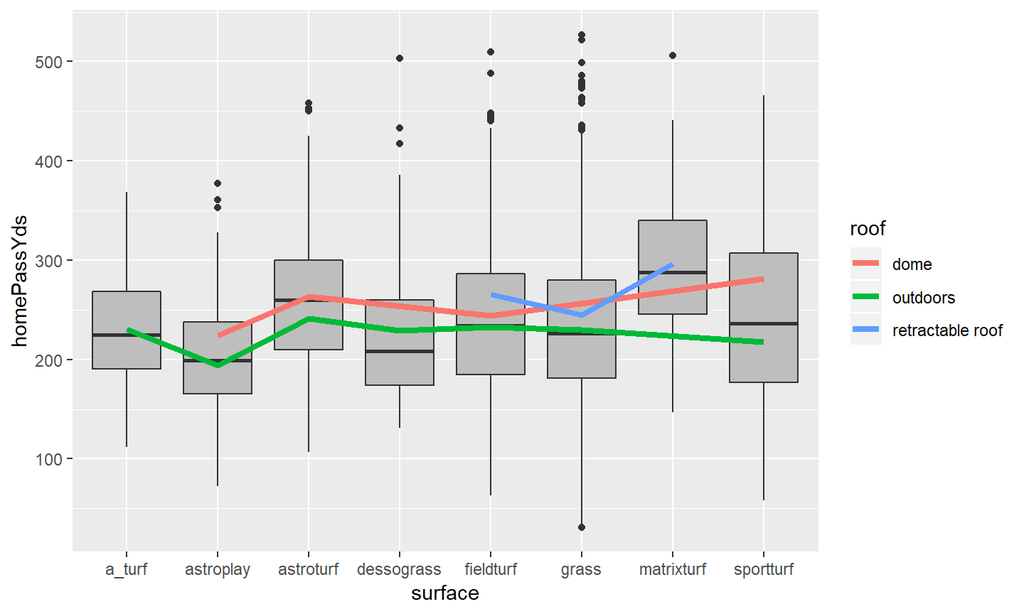

## Graphical Summaries

**Quantitative Data** - plots use ggplot2 (Line Plot)

- Connects dots
- Most useful with a time type variable

## Graphical Summaries

**Quantitative Data** - plots use ggplot2 (Line Plot)

- Connects dots
- Most useful with a time type variable

```r
oneDate <- paste(scoresFull$date[1], scoresFull$season[1], sep = "-"); oneDate
```

```
## [1] "5-Sep-2002"
```

```r
unite(scoresFull, Date, sep = "-", date, season, remove = FALSE) %>% select(Date, everything())
```

```
## # A tibble: 3,471 x 83
##   Date  week  date  day   season awayTeam   AQ1   AQ2   AQ3   AQ4   AOT
##   <chr> <chr> <chr> <chr>  <int> <chr>    <int> <int> <int> <int> <int>
## 1 5-Se~ 1     5-Sep Thu     2002 San Fra~     3     0     7     6    -1
## 2 8-Se~ 1     8-Sep Sun     2002 Minneso~     3    17     0     3    -1
## 3 8-Se~ 1     8-Sep Sun     2002 New Orl~     6     7     7     0     6
## 4 8-Se~ 1     8-Sep Sun     2002 New Yor~     0    17     3    11     6
## 5 8-Se~ 1     8-Sep Sun     2002 Arizona~    10     3     3     7    -1
## # ... with 3,466 more rows, and 72 more variables: AOT2 <int>,
## #   AFinal <int>, homeTeam <chr>, HQ1 <int>, HQ2 <int>, HQ3 <int>,
## #   HQ4 <int>, HOT <int>, HOT2 <int>, HFinal <int>, stadium <chr>,
## #   startTime <time>, toss <chr>, roof <chr>, surface <chr>,
## #   duration <int>, attendance <chr>, weather <chr>, vegasLine <chr>,
## #   OU <chr>, AfirstDowns <int>, AnetPassYds <int>, AtotalYds <int>,
## #   Aturnovers <int>, AtotalPlays <int>, HfirstDowns <int>,
## #   HnetPassYds <int>, HtotalYds <int>, Hturnovers <int>,
## #   HtotalPlays <int>, OUvalue <dbl>, OUresult <chr>, awayRushAtt <int>,
## #   awayRushYds <int>, awayRushTD <int>, awayPassComp <int>,
## #   awayPassAtt <int>, awayPassYds <int>, awayPassTD <int>,
## #   awayPassInt <int>, awayTimesSacked <int>, awaySackYdsLost <int>,
## #   awayFum <int>, awayFumLost <int>, awayNumPen <int>, awayPenYds <int>,
## #   away3rdConv <int>, away3rdAtt <int>, away4thConv <int>,
## #   away4thAtt <int>, awayTOP <dbl>, homeRushAtt <int>, homeRushYds <int>,
## #   homeRushTD <int>, homePassComp <int>, homePassAtt <int>,
## #   homePassYds <int>, homePassTD <int>, homePassInt <int>,
## #   homeTimesSacked <int>, homeSackYdsLost <int>, homeFum <int>,
## #   homeFumLost <int>, homeNumPen <int>, homePenYds <int>,
## #   home3rdConv <int>, home3rdAtt <int>, home4thConv <int>,
## #   home4thAtt <int>, homeTOP <dbl>, HminusAScore <int>, homeSpread <dbl>
```

## Graphical Summaries

**Aside: Working with Dates**

- `lubridate` package great for dates!
- Dates can be added and subtracted
- Are # of days since Jan 1, 1970

```r
library(lubridate)
as.Date(oneDate,"%d-%b-%Y")
```

```
## [1] "2002-09-05"
```

```r
as.Date(oneDate,"%d-%b-%Y") + 1
```

```
## [1] "2002-09-06"
```

## Graphical Summaries

**Quantitative Data** - plots use ggplot2 (Line Plot)

- Create full date variable for fun
- Summarise total yards for AFC North team home games for each year

```r
scoresFull <- unite(scoresFull, Date, sep = "-", date, season, remove = FALSE)
scoresFull$Date <- as.Date(scoresFull$Date, "%d-%b-%Y")

subScores <- scoresFull %>%
  filter(homeTeam %in% c("Pittsburgh Steelers", "Cleveland Browns",
                         "Baltimore Ravens", "Cincinnati Bengals")) %>%
  group_by(season, homeTeam) %>%
  summarise(homeAvgYds = mean(homePassYds + homeRushYds))
```

## Graphical Summaries

**Quantitative Data** - plots use ggplot2 (Line Plot)

```r
subScores
```

```
## # A tibble: 52 x 3
## # Groups:   season [13]
##   season homeTeam            homeAvgYds
##    <int> <chr>                    <dbl>
## 1   2002 Baltimore Ravens          294
## 2   2002 Cincinnati Bengals        326
## 3   2002 Cleveland Browns          325.
## 4   2002 Pittsburgh Steelers       408.
## 5   2003 Baltimore Ravens          333.
## # ... with 47 more rows
```

## Graphical Summaries

**Quantitative Data** - plots use ggplot2 (Line Plot)

```r
g <- ggplot(subScores, aes(x = season, y = homeAvgYds, color = homeTeam))
g + geom_line(lwd = 1.5)
```

## Graphical Summaries

**Quantitative Data** - plots use ggplot2 (Line Plot)

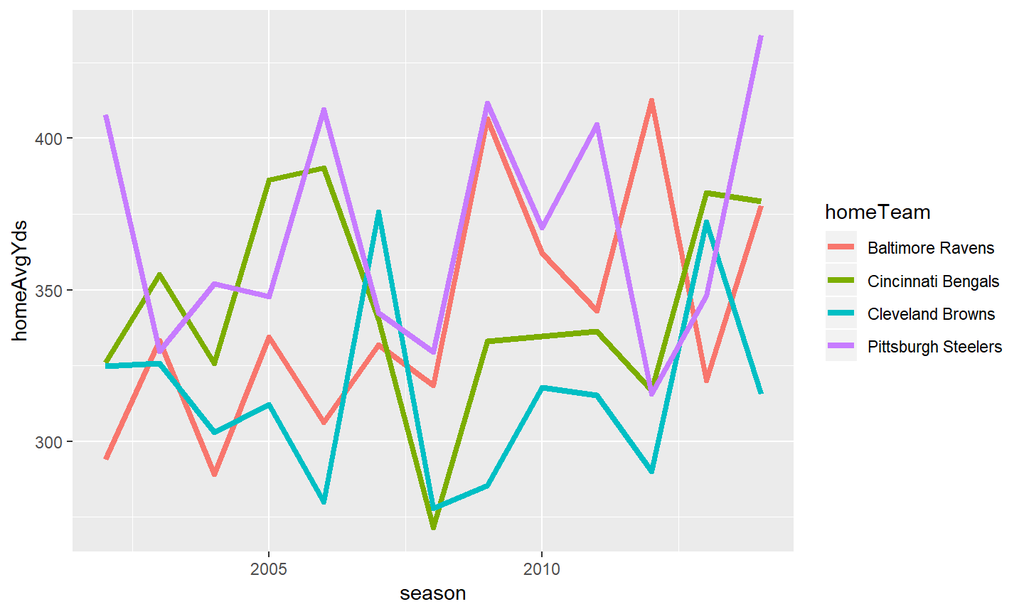

## Recap!

- How to summarize quantitative data?
- Numerically?
  - Many summary stats. Focus often on
    - Center, Spread, Linear Relationship
- Graphically?
  - One variable: Kernel Density/Histogram
  - Two variables: Scatter plots
- Important to view your data together **and** broken down into subsets!

## Recap!

`ggplot2` package quite useful for easy plotting

`ggplot(data = <DATA>) +`  
`<GEOM_FUNCTION>(`  
`mapping = aes(<MAPPINGS>),`  
`stat = <STAT>,`  
`position = <POSITION>`  
`) +`  
`<COORDINATE_FUNCTION> +`  
`<FACET_FUNCTION> +`  
`<LABEL_FUNCTION>`  
`)`